# OBIS QA/QC R Notebook

## Getting started

Installing and loading required R packages

```r
if(!requireNamespace("obistools")){
  if(!requireNamespace("devtools")){
    install.packages("devtools")
  }
  devtools::install_github("iobis/obistools")
}
if(!requireNamespace("robis")){
  install.packages("robis")
}
if(!requireNamespace("sf")){
  install.packages("sf")
}
library(obistools)
library(sf)
```

Help and issues

- Manual: http://www.iobis.org/manual/processing/
- Issues: https://github.com/iobis/obistools/issues

## Generate a report

View points on a map and check missing fields, event dates, depth values, points on land, …

```r
# Warning: This doens't really play well with R notebook as it generates lots of output
report(abra, file="abra_report.html", dir=".")
```

abra_report.html

## Check required fields

```r
check_fields(abra)
```

| field | level | message |
| --- | --- | --- |
| occurrenceStatus | error | Required field occurrenceStatus is missing |

occurrenceStatus: A statement about the presence or absence of a Taxon at a Location.  
http://rs.tdwg.org/dwc/terms/#occurrenceStatus

## Map column names to Darwin Core terms

```r
data <- data.frame(
  id = c("cruise_1", "station_1", "station_2", "sample_1", "sample_2", "sample_3", "sample_4", "subsample_1", "subsample_2"),
  date = c(NA, NA, NA, "2017-01-01", "2017-01-02", "2017-01-03", "2017-01-04", NA, NA),
  locality = rep("North Sea", 9),
  lon = c(NA, 2.9, 4.7, NA, NA, NA, NA, NA, NA),
  lat = c(NA, 54.1, 55.8, NA, NA, NA, NA, NA, NA),
  stringsAsFactors = FALSE)
mapping <- list(
  decimalLongitude = "lon", decimalLatitude = "lat",
  datasetName = "dataset", eventID = "id", eventDate = "date")
map_fields(data, mapping)
```

| eventID | eventDate | locality | decimalLongitude | decimalLatitude |
| --- | --- | --- | --- | --- |
| cruise_1 | NA | North Sea | NA | NA |
| station_1 | NA | North Sea | 2.9 | 54.1 |
| station_2 | NA | North Sea | 4.7 | 55.8 |
| sample_1 | 2017-01-01 | North Sea | NA | NA |
| sample_2 | 2017-01-02 | North Sea | NA | NA |
| sample_3 | 2017-01-03 | North Sea | NA | NA |
| sample_4 | 2017-01-04 | North Sea | NA | NA |
| subsample_1 | NA | North Sea | NA | NA |
| subsample_2 | NA | North Sea | NA | NA |

## Taxon matching

Interactive taxon matching with the World Register of Marine Species (WoRMS)

```r
# This is interactive code, if you run it check the console
taxa <- c("Abra alva", "Buccinum fusiforme", "Buccinum fusiforme", "hlqsdkf")
matched_taxa <- match_taxa(taxa)
matched_taxa
```

## Checking points on land

```r
onland <- check_onland(abra)
onland[,1:5]
```

|  | id | decimalLongitude | decimalLatitude | basisOfRecord | eventDate |
| --- | --- | --- | --- | --- | --- |
| 31 | 365512845 | -0.9092748 | 54.57467 | Occurrence | 2011-09-03 10:00:00 |

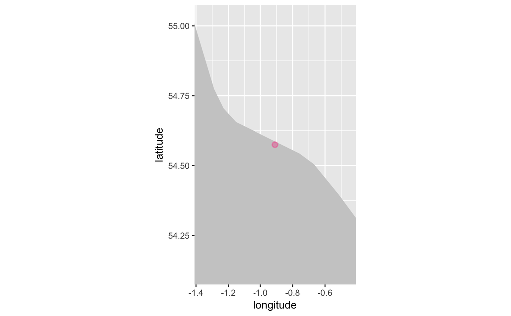

```r
plot_map(onland, zoom = TRUE)
```

```r
robis::leafletmap(onland)
```

[interactive chart not shown]

## Checking depth values

```r
depthreport <- check_depth(abra, report = TRUE)
depthreport[1:10, ]
```

|  | field | level | row | message |
| --- | --- | --- | --- | --- |
| 1 | minimumDepthInMeters | warning | 34 | Depth value (15.9) is greater than the value found in the bathymetry raster (depth=14.6, margin=0) |
| 2 | minimumDepthInMeters | warning | 35 | Depth value (15.9) is greater than the value found in the bathymetry raster (depth=14.6, margin=0) |
| 3 | minimumDepthInMeters | warning | 36 | Depth value (23.7) is greater than the value found in the bathymetry raster (depth=20.2, margin=0) |
| 4 | minimumDepthInMeters | warning | 37 | Depth value (24.8) is greater than the value found in the bathymetry raster (depth=20.2, margin=0) |
| 5 | minimumDepthInMeters | warning | 47 | Depth value (19.4) is greater than the value found in the bathymetry raster (depth=18.6, margin=0) |
| 6 | minimumDepthInMeters | warning | 51 | Depth value (23.4) is greater than the value found in the bathymetry raster (depth=18.6, margin=0) |
| 7 | minimumDepthInMeters | warning | 52 | Depth value (23.8) is greater than the value found in the bathymetry raster (depth=18.6, margin=0) |
| 8 | minimumDepthInMeters | warning | 54 | Depth value (8.5) is greater than the value found in the bathymetry raster (depth=7.2, margin=0) |
| 9 | minimumDepthInMeters | warning | 55 | Depth value (8.75) is greater than the value found in the bathymetry raster (depth=7.2, margin=0) |
| 10 | minimumDepthInMeters | warning | 56 | Depth value (8.9) is greater than the value found in the bathymetry raster (depth=7.2, margin=0) |

```r
robis::leafletmap(abra[depthreport$row,])
```

[interactive chart not shown]

Extra parameters for `check_depth`:

- `depthmargin`: How much can the given depth deviate from the bathymetry in the rasters (in meters).
- `shoremargin`: How far offshore (in meters) should a record be to have a bathymetry greater than 0. If NA (default) then this test is ignored.
- `bathymetry`: Raster* object that you want to use to check the depth against. If NULL (default) then the bathymetry from the xylookup service is used.

## Lookup XY

Data for on land and depth checks is provided by the xylookup service which can be called trough the `lookup_xy` function.

```r
env <- lookup_xy(abra)
summary(env)
```

```
 shoredistance    sstemperature      sssalinity       bathymetry
 Min.   :  -194   Min.   : 9.726   Min.   : 7.532   Min.   :-88.00
 1st Qu.:   321   1st Qu.:10.109   1st Qu.:17.248   1st Qu.:  7.00
 Median :  1680   Median :10.298   Median :24.227   Median : 13.60
 Mean   :  3775   Mean   :10.543   Mean   :25.469   Mean   : 13.52
 3rd Qu.:  4150   3rd Qu.:10.462   3rd Qu.:34.827   3rd Qu.: 18.80
 Max.   :157067   Max.   :15.929   Max.   :35.334   Max.   :311.00
                  NA's   :58       NA's   :58
```

## Check event date

```r
data_nodate <- data.frame(
  scientificName = c("Abra alba", "Lanice conchilega"),
  stringsAsFactors = FALSE)
check_eventdate(data_nodate)
```

| level | message |
| --- | --- |
| error | Column eventDate missing |

```r
data_goodformats <- data.frame(
  eventDate = c(
    "2016",
    "2016-01",
    "2016-01-02",
    "2016-01-02 13:00",
    "2016-01-02T13:00",
    "2016-01-02 13:00:00/2016-01-02 14:00:00",
    "2016-01-02 13:00:00/14:00:00"),
  stringsAsFactors = FALSE)
check_eventdate(data_goodformats)
```

```r
data_badformats <- data.frame(
  eventDate = c(
    "2016/01/02",
    "2016-01-02 13h00"),
  stringsAsFactors = FALSE)
check_eventdate(data_badformats)
```

| level | row | field | message |
| --- | --- | --- | --- |
| error | 1 | eventDate | eventDate 2016/01/02 does not seem to be a valid date |
| error | 2 | eventDate | eventDate 2016-01-02 13h00 does not seem to be a valid date |

## Dataset structure

```r
archive <- hyperbenthos$data
archive$extendedmeasurementorfact.txt$eventID <- archive$extendedmeasurementorfact.txt$id
tree <- treeStructure(archive$event.txt, archive$occurrence.txt,
                      archive$extendedmeasurementorfact.txt)
exportTree(tree, "hyperbenthos_tree.html")
```

hyperbenthos_tree.html

## Check eventID and parentEventID

`check_eventids()` checks if both `eventID()` and `parentEventID` fields are present in an event table, and if al `parentEventID`s have a corresponding `eventID`.

```r
data <- data.frame(
  eventID = c("a", "b", "c", "d", "e", "f"),
  parentEventID = c("", "", "a", "a", "z", "b"),
  stringsAsFactors = FALSE
)
check_eventids(data)
```

| field | level | row | message |
| --- | --- | --- | --- |
| parentEventID | error | 5 | parentEventID z has no corresponding eventID |

## Check eventID in an extension

`check_extension_eventids()` checks if all `eventID`s in an extension have matching `eventID`s in the core table.

```r
event <- data.frame(
  eventID = c("cruise_1", "station_1", "station_2",
              "sample_1", "sample_2", "sample_3", "sub_1", "sub_2"),
  parentEventID = c(NA, "cruise_1", "cruise_1", "station_1", "station_1", "station_2",
                    "sample_3", "sample_3"),
  eventDate = c(NA, NA, NA, "2017-01-01", "2017-01-02", "2017-01-03", NA, NA),
  decimalLongitude = c(NA, 2.9, 4.7, NA, NA, NA, NA, NA),
  decimalLatitude = c(NA, 54.1, 55.8, NA, NA, NA, NA, NA),
  stringsAsFactors = FALSE)
event
```

| eventID | parentEventID | eventDate | decimalLongitude | decimalLatitude |
| --- | --- | --- | --- | --- |
| cruise_1 | NA | NA | NA | NA |
| station_1 | cruise_1 | NA | 2.9 | 54.1 |
| station_2 | cruise_1 | NA | 4.7 | 55.8 |
| sample_1 | station_1 | 2017-01-01 | NA | NA |
| sample_2 | station_1 | 2017-01-02 | NA | NA |
| sample_3 | station_2 | 2017-01-03 | NA | NA |
| sub_1 | sample_3 | NA | NA | NA |
| sub_2 | sample_3 | NA | NA | NA |

```r
occurrence <- data.frame(
  eventID = c("sample_1","sample_1","sample_28","sample_2","sample_3","sub_1"),
  scientificName = c("Abra alba", "Lanice conchilega", "Pectinaria koreni",
                     "Nephtys hombergii", "Pectinaria koreni", "Abra alba"),
  stringsAsFactors = FALSE)
occurrence
```

| eventID | scientificName |
| --- | --- |
| sample_1 | Abra alba |
| sample_1 | Lanice conchilega |
| sample_28 | Pectinaria koreni |
| sample_2 | Nephtys hombergii |
| sample_3 | Pectinaria koreni |
| sub_1 | Abra alba |

```r
check_extension_eventids(event, occurrence)
```

| field | level | row | message |
| --- | --- | --- | --- |
| eventID | error | 3 | eventID sample_28 has no corresponding eventID in the core |

## Flatten event records

`flatten_event()` recursively adds event information from parent to child events.

```r
event
```

| eventID | parentEventID | eventDate | decimalLongitude | decimalLatitude |
| --- | --- | --- | --- | --- |
| cruise_1 | NA | NA | NA | NA |
| station_1 | cruise_1 | NA | 2.9 | 54.1 |
| station_2 | cruise_1 | NA | 4.7 | 55.8 |
| sample_1 | station_1 | 2017-01-01 | NA | NA |
| sample_2 | station_1 | 2017-01-02 | NA | NA |
| sample_3 | station_2 | 2017-01-03 | NA | NA |
| sub_1 | sample_3 | NA | NA | NA |
| sub_2 | sample_3 | NA | NA | NA |

```r
flatten_event(event)
```

| eventID | parentEventID | eventDate | decimalLongitude | decimalLatitude |
| --- | --- | --- | --- | --- |
| cruise_1 | NA | NA | NA | NA |
| station_1 | cruise_1 | NA | 2.9 | 54.1 |
| station_2 | cruise_1 | NA | 4.7 | 55.8 |
| sample_1 | station_1 | 2017-01-01 | 2.9 | 54.1 |
| sample_2 | station_1 | 2017-01-02 | 2.9 | 54.1 |
| sample_3 | station_2 | 2017-01-03 | 4.7 | 55.8 |
| sub_1 | sample_3 | 2017-01-03 | 4.7 | 55.8 |
| sub_2 | sample_3 | 2017-01-03 | 4.7 | 55.8 |

## Flatten occurrence and event records

`flatten_occurrence()` will add event information to occurrence records.

```r
occurrence <- data.frame(
  eventID = c("sample_1","sample_1","sample_2","sample_2","sample_3","sub_1"),
  scientificName = c("Abra alba", "Lanice conchilega", "Pectinaria koreni",
                     "Nephtys hombergii", "Pectinaria koreni", "Abra alba"),
  stringsAsFactors = FALSE)
occurrence
```

| eventID | scientificName |
| --- | --- |
| sample_1 | Abra alba |
| sample_1 | Lanice conchilega |
| sample_2 | Pectinaria koreni |
| sample_2 | Nephtys hombergii |
| sample_3 | Pectinaria koreni |
| sub_1 | Abra alba |

```r
flatten_occurrence(event, occurrence)
```

| eventID | scientificName | eventDate | decimalLatitude | decimalLongitude |
| --- | --- | --- | --- | --- |
| sample_1 | Abra alba | 2017-01-01 | 54.1 | 2.9 |
| sample_1 | Lanice conchilega | 2017-01-01 | 54.1 | 2.9 |
| sample_2 | Pectinaria koreni | 2017-01-02 | 54.1 | 2.9 |
| sample_2 | Nephtys hombergii | 2017-01-02 | 54.1 | 2.9 |
| sample_3 | Pectinaria koreni | 2017-01-03 | 55.8 | 4.7 |
| sub_1 | Abra alba | 2017-01-03 | 55.8 | 4.7 |

## Calculate centroid and radius for WKT geometries

WKT: text representation for geometries https://en.wikipedia.org/wiki/Well-known_text

```
POINT (30 10)
LINESTRING (30 10, 10 30, 40 40)
POLYGON ((30 10, 40 40, 20 40, 10 20, 30 10))
```

`calculate_centroid()` calculates a centroid and radius for WKT strings. This is useful for populating `decimalLongitiude`, `decimalLatitude` and `coordinateUncertaintyInMeters`.

```r
wkt <- c(
  "POLYGON ((2.5378 51.1242, 2.9937 51.3203, 3.3453 51.3957, 2.2741 51.6998, 2.5378 51.1242))",
  "POLYGON ((3.1558 42.2356, 3.1324 42.1420, 3.2203 42.1124, 3.2601 42.2153, 3.1558 42.2356))"
)
centroid <- calculate_centroid(wkt)
centroid
```

| decimalLongitude | decimalLatitude | coordinateUncertaintyInMeters |
| --- | --- | --- |
| 2.719067 | 51.40717 | 44860.608 |
| 3.193506 | 42.17714 | 7524.069 |

```r
features <- sf::st_as_sfc(wkt)
map <- robis::leafletmap(centroid)
leaflet::addPolygons(map, data = features)
```

[interactive chart not shown]